# Subset Variable Selection

# 1 Objective

The objective of this case is to get you started with regression model building, variable selection, and model evaluation in R.

We use Boston Housing Data as an illustrative example in this lab. We learn basic linear regression and analysis with R. Code in this file is not the only correct way to do things, however it is important for you to understand what each statement does. You will have to modify the code accordingly for your homework.

# 2 Boston Housing Data

Boston housing data is a built-in dataset in `MASS` package, so you do not need to download externally. Package `MASS` comes with R when you installed R, so no need to use `install.packages(MASS)` to download and install, but you do need to load this package.

## 2.1 Load Data

```r
library(MASS)
data(Boston); #this data is in MASS package
colnames(Boston)
```

```
##  [1] "crim"    "zn"      "indus"   "chas"    "nox"     "rm"      "age"
##  [8] "dis"     "rad"     "tax"     "ptratio" "black"   "lstat"   "medv"
```

You can find details of the dataset from help document.

```r
?Boston
```

We skip the Exploratory Data Analysis (EDA) in this notes, but you should not omit it in your HW and Cases. EDA is very important and always the first analysis to do before any modeling.

## 2.2 Preparation

### 2.2.1 Splitting data to training and testing samples

Next we sample 90% of the original data and use it as the training set. The remaining 10% is used as test set. The regression model will be built on the training set and future performance of your model will be evaluated with the test set.

```r
sample_index <- sample(nrow(Boston),nrow(Boston)*0.90)
Boston_train <- Boston[sample_index,]
Boston_test <- Boston[-sample_index,]
```

### 2.2.2 (Optional) Standardization

If we want our results to be invariant to the units and the parameter estimates $\beta_i$ to be comparible, we can standardize the variables. Essentially we are replacing the original values with their z-score.

1st Way: create new variables manually.

```r
Boston$sd.crim <- (Boston$crim-mean(Boston$crim))/sd(Boston$crim);
```

This does the same thing.

```r
Boston$sd.crim <- scale(Boston$crim);
```

2nd way: If you have a lot of variables to standardize then the above is not very pleasing to do. You can use a loop like this. It standardizes every varables other than the last one which is $y$.

```r
for (i in 1:(ncol(Boston_train)-1)){
  Boston_train[,i] <- scale(Boston_train[,i])
}
```

The technique is not as important in linear regression because it will only affect the interpretation but not the model estimation and inference.

go to top

# 3 Variable Selection

## 3.1 Compare Model Fit Manually

```r
model_1 <- lm(medv~., data = Boston_train)
model_2 <- lm(medv~crim+zn, data = Boston_train)
summary(model_1)
summary(model_2)
AIC(model_1); BIC(model_1)
AIC(model_2); BIC(model_2)
```

## 3.2 Best Subset Regression

The ‘leaps’ package provides procedures for best subset regression.

```r
install.packages('leaps')
```

```r
library(leaps)
```

Which subset of variables should you include in order to minimize BIC?

```r
#regsubsets only takes data frame as input
subset_result <- regsubsets(medv~.,data=Boston_train, nbest=2, nvmax = 14)
summary(subset_result)
```

```
## Subset selection object
## Call: regsubsets.formula(medv ~ ., data = Boston_train, nbest = 2,
##     nvmax = 14)
## 13 Variables  (and intercept)
##         Forced in Forced out
## crim        FALSE      FALSE
## zn          FALSE      FALSE
## indus       FALSE      FALSE
## chas        FALSE      FALSE
## nox         FALSE      FALSE
## rm          FALSE      FALSE
## age         FALSE      FALSE
## dis         FALSE      FALSE
## rad         FALSE      FALSE
## tax         FALSE      FALSE
## ptratio     FALSE      FALSE
## black       FALSE      FALSE
## lstat       FALSE      FALSE
## 2 subsets of each size up to 13
## Selection Algorithm: exhaustive
##           crim zn  indus chas nox rm  age dis rad tax ptratio black lstat
## 1  ( 1 )  " "  " " " "   " "  " " " " " " " " " " " " " "     " "   "*"
## 1  ( 2 )  " "  " " " "   " "  " " "*" " " " " " " " " " "     " "   " "
## 2  ( 1 )  " "  " " " "   " "  " " "*" " " " " " " " " " "     " "   "*"
## 2  ( 2 )  " "  " " " "   " "  " " " " " " " " " " " " "*"     " "   "*"
## 3  ( 1 )  " "  " " " "   " "  " " "*" " " " " " " " " "*"     " "   "*"
## 3  ( 2 )  " "  " " " "   "*"  " " "*" " " " " " " " " " "     " "   "*"
## 4  ( 1 )  " "  " " " "   " "  " " "*" " " "*" " " " " "*"     " "   "*"
## 4  ( 2 )  " "  " " " "   "*"  " " "*" " " " " " " " " "*"     " "   "*"
## 5  ( 1 )  " "  " " " "   " "  "*" "*" " " "*" " " " " "*"     " "   "*"
## 5  ( 2 )  " "  " " " "   " "  " " "*" " " "*" " " " " "*"     "*"   "*"
## 6  ( 1 )  " "  " " " "   "*"  "*" "*" " " "*" " " " " "*"     " "   "*"
## 6  ( 2 )  " "  " " " "   " "  "*" "*" " " "*" " " " " "*"     "*"   "*"
## 7  ( 1 )  " "  " " " "   "*"  "*" "*" " " "*" " " " " "*"     "*"   "*"
## 7  ( 2 )  " "  "*" " "   "*"  "*" "*" " " "*" " " " " "*"     " "   "*"
## 8  ( 1 )  " "  "*" " "   "*"  "*" "*" " " "*" " " " " "*"     "*"   "*"
## 8  ( 2 )  " "  " " " "   "*"  "*" "*" " " "*" "*" " " "*"     "*"   "*"
## 9  ( 1 )  "*"  " " " "   "*"  "*" "*" " " "*" "*" " " "*"     "*"   "*"
## 9  ( 2 )  " "  " " " "   "*"  "*" "*" " " "*" "*" "*" "*"     "*"   "*"
## 10  ( 1 ) "*"  " " " "   "*"  "*" "*" " " "*" "*" "*" "*"     "*"   "*"
## 10  ( 2 ) "*"  "*" " "   "*"  "*" "*" " " "*" "*" " " "*"     "*"   "*"
## 11  ( 1 ) "*"  "*" " "   "*"  "*" "*" " " "*" "*" "*" "*"     "*"   "*"
## 11  ( 2 ) "*"  "*" "*"   "*"  "*" "*" " " "*" "*" " " "*"     "*"   "*"
## 12  ( 1 ) "*"  "*" " "   "*"  "*" "*" "*" "*" "*" "*" "*"     "*"   "*"
## 12  ( 2 ) "*"  "*" "*"   "*"  "*" "*" " " "*" "*" "*" "*"     "*"   "*"
## 13  ( 1 ) "*"  "*" "*"   "*"  "*" "*" "*" "*" "*" "*" "*"     "*"   "*"
```

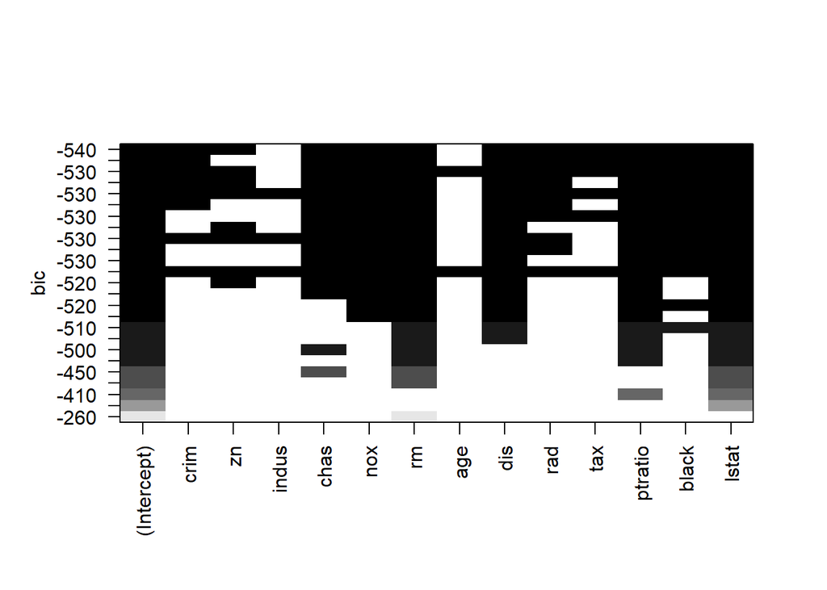

```r
plot(subset_result, scale="bic")
```

Each row represents a model. Black indicates that a variable is included in the model, while white indicates that it is not. The argument `scale = ""` can be “Cp”, “adjr2”, “r2” or “bic”.

What is the problem with best subset regression? If there are n independent variables, the number of possible nonempty subsets is 2^n - 1. If you try a best subset regression with more than 50 variables, you might need to wait for your entire life to get the result.

## 3.3 Forward/Backward/Stepwise Regression Using AIC

To perform the Forward/Backward/Stepwise Regression in R, we need to define the starting points:

```r
nullmodel=lm(medv~1, data=Boston_train)
fullmodel=lm(medv~., data=Boston_train)
```

nullmodel is the model with no varaible in it, while fullmodel is the model with every variable in it.

### 3.3.1 Backward Elimination

```r
model_step_b <- step(fullmodel,direction='backward')
```

```
## Start:  AIC=1414.6
## medv ~ crim + zn + indus + chas + nox + rm + age + dis + rad +
##     tax + ptratio + black + lstat
##
##           Df Sum of Sq     RSS    AIC
## - indus    1      4.04  9587.4 1412.8
## - age      1      8.51  9591.8 1413.0
## <none>                  9583.3 1414.6
## - tax      1    228.77  9812.1 1423.3
## - chas     1    247.40  9830.7 1424.2
## - black    1    248.77  9832.1 1424.3
## - zn       1    256.52  9839.9 1424.6
## - crim     1    262.30  9845.6 1424.9
## - nox      1    393.50  9976.8 1430.9
## - rad      1    482.65 10066.0 1435.0
## - dis      1    974.86 10558.2 1456.7
## - ptratio  1   1095.60 10678.9 1461.9
## - rm       1   1263.97 10847.3 1469.0
## - lstat    1   2521.44 12104.8 1518.9
##
## Step:  AIC=1412.8
## medv ~ crim + zn + chas + nox + rm + age + dis + rad + tax +
##     ptratio + black + lstat
##
##           Df Sum of Sq     RSS    AIC
## - age      1      8.32  9595.7 1411.2
## <none>                  9587.4 1412.8
## - black    1    247.17  9834.5 1422.4
## - zn       1    252.55  9839.9 1422.6
## - tax      1    256.00  9843.4 1422.8
## - chas     1    258.04  9845.4 1422.9
## - crim     1    265.27  9852.6 1423.2
## - nox      1    398.92  9986.3 1429.3
## - rad      1    501.81 10089.2 1434.0
## - dis      1   1052.53 10639.9 1458.2
## - ptratio  1   1096.59 10684.0 1460.1
## - rm       1   1260.44 10847.8 1467.0
## - lstat    1   2525.59 12113.0 1517.2
##
## Step:  AIC=1411.19
## medv ~ crim + zn + chas + nox + rm + dis + rad + tax + ptratio +
##     black + lstat
##
##           Df Sum of Sq     RSS    AIC
## <none>                  9595.7 1411.2
## - zn       1    245.80  9841.5 1420.7
## - tax      1    253.18  9848.9 1421.0
## - black    1    254.08  9849.8 1421.1
## - chas     1    263.17  9858.9 1421.5
## - crim     1    264.64  9860.3 1421.6
## - nox      1    400.95  9996.6 1427.8
## - rad      1    494.21 10089.9 1432.0
## - ptratio  1   1088.28 10684.0 1458.1
## - dis      1   1206.68 10802.4 1463.1
## - rm       1   1361.14 10956.8 1469.5
## - lstat    1   2743.76 12339.4 1523.6
```

### 3.3.2 Forward Selection

```r
model_step_f <- step(nullmodel, scope=list(lower=nullmodel, upper=fullmodel), direction='forward')
```

```
## Start:  AIC=2002.21
## medv ~ 1
##
##           Df Sum of Sq   RSS    AIC
## + lstat    1   20223.1 16692 1643.1
## + rm       1   16819.5 20095 1727.5
## + ptratio  1    9756.5 27158 1864.6
## + indus    1    8384.2 28531 1887.0
## + tax      1    8001.7 28913 1893.0
## + nox      1    6767.3 30148 1912.1
## + crim     1    5715.3 31200 1927.7
## + rad      1    5262.1 31653 1934.2
## + age      1    5182.3 31733 1935.4
## + zn       1    4708.0 32207 1942.1
## + black    1    4177.3 32738 1949.6
## + dis      1    2390.4 34525 1973.8
## + chas     1    1686.7 35228 1982.9
## <none>                 36915 2002.2
##
## Step:  AIC=1643.08
## medv ~ lstat
##
##           Df Sum of Sq   RSS    AIC
## + rm       1   3120.98 13571 1550.9
## + ptratio  1   2326.50 14365 1576.8
## + chas     1    936.66 15755 1618.8
## + dis      1    679.89 16012 1626.2
## + age      1    308.54 16383 1636.6
## + tax      1    194.61 16497 1639.8
## + black    1    175.45 16516 1640.3
## + crim     1    146.10 16546 1641.1
## + zn       1    122.78 16569 1641.7
## <none>                 16692 1643.1
## + indus    1     50.96 16641 1643.7
## + rad      1      7.46 16684 1644.9
## + nox      1      7.22 16685 1644.9
##
## Step:  AIC=1550.9
## medv ~ lstat + rm
##
```

[output cut: 109 more lines]

```
##
##         Df Sum of Sq    RSS    AIC
## + tax    1   253.184 9595.7 1411.2
## <none>               9848.9 1421.0
## + indus  1    31.253 9817.6 1421.6
## + age    1     5.508 9843.4 1422.8
##
## Step:  AIC=1411.19
## medv ~ lstat + rm + ptratio + dis + nox + chas + black + zn +
##     crim + rad + tax
##
##         Df Sum of Sq    RSS    AIC
## <none>               9595.7 1411.2
## + age    1    8.3200 9587.4 1412.8
## + indus  1    3.8457 9591.8 1413.0
```

### 3.3.3 Stepwise Selection (Output Omitted)

```r
model_step_s <- step(nullmodel, scope=list(lower=nullmodel, upper=fullmodel), direction='both')
```

One caution when comparing fit statistics using AIC, the definition varies by program/procedure.

```r
model_1 <- lm(medv~crim+zn+chas+nox+rm+dis+rad+tax+ptratio+black+lstat, data=Boston_train)
extractAIC(model_1)
```

```
## [1]   12.000 1411.191
```

```r
AIC(model_1)
```

```
## [1] 2704.425
```

> Exercise
> 1. Compare in-sample and out-of-sample performance between these reduced models.
- For pros and cons of variable/model selection using the common fit statistics: (adjusted) $R^2$, MSE, AIC, BIC, etc. refer to Ch9 in “Applied Linear Regression Models” by Kutner et al.
- For other variable selection methods refer to section 3.4 - 3.8 of [“Elements of Statistical Learning” (Free Online)](http://www-stat.stanford.edu/~tibs/ElemStatLearn/).

go to top